# Discrete Distributions

Yuji Saikai ysaikai@unimelb.edu.au School of Mathematics and Statistics The University of Melbourne

19 April 2021

These notes are based on Chapter 15 of Jones, O., Maillardet, R., & Robinson, A. (2009). *Introduction to scientific programming and simulation using R*. CRC Press.

# Discrete distributions

R recognises common distributions by short names and specifies them by parameters.

| Distribution | R name | R Parameters | Abbreviation |
| --- | --- | --- | --- |
| Bernoulli | `binom` | `size=1`, `prob` | $\mathrm{Bernoulli}(p)$ |
| Binomial | `binom` | `size`, `prob` | $\mathrm{binom}(n,p)$ |
| Geometric | `geom` | `prob` | $\mathrm{geom}(p)$ |
| Negative binomial | `nbinom` | `size`, `prob` | $\mathrm{nbinom}(r,p)$ |
| Poisson | `pois` | `lambda` | $\mathrm{pois}(\lambda)$ |

> As you see below, $\mathrm{Bernoulli}(p)$ is equivalent to $\mathrm{binom}(1,p)$.

R built-in functions for common distributions follow a certain pattern. Suppose that a distribution is recognised by name `xyz` and specified by parameters `p1` and `p2`, then R provides the following four functions to help you work with the distribution.

- `dxyz(x, p1, p2, ...)` returns $P(X=x)$, the value of PMF at $x$.
- `pxyz(q, p1, p2, ...)` returns $F(q)$, the value of CDF at $q$.
- `qxyz(p, p1, p2, ...)` returns $\arg\min_x F(x)\geq p$, i.e., the [quantile function](https://en.wikipedia.org/wiki/Quantile_function).
- `rxyz(n, p1, p2, ...)` returns $n$ random samples.

> In these notes, I avoid using $p(x)$ for PMF but use $P(X=x)$ to describe the distribution of $X$ since we are going to use lots of $p$ below.

> The support of $X$ means the set $\{x\in\mathbb{R} : P(X=x)>0\}$ for discrete $X$ or $\{x\in\mathbb{R} : f(x)>0\}$ for continuous $X$ where $f$ is a PDF of $X$.

## Bernoulli

The support is $\{0,1\}$, which is often interpreted as “failure” and “success” respectively. Naturally, it has a single success parameter $p\in(0,1)$ that specifies the probability of “success”, i.e. $p = P(X=1)$.

Bernoulli distribution serves as a fundamental building block and, as you will see below, many complex distributions can be modelled as a sequence of independent Bernoulli trials.

$$\begin{align}
P(X=x) &=
\begin{cases}
p & \text{for } x=1\\
1 - p & \text{for } x=0
\end{cases}\\\\
\mathbb{E}X &= \sum_{x\in\{0,1\}} xP(X=x)\\
&= 0\cdot(1-p)+1\cdot p\\
&= p\\\\
\operatorname{Var} X &= \sum_{x\in\{0,1\}} (x-p)^2P(X=x)\\
&= (0-p)^2\cdot(1-p) + (1-p)^2\cdot p\\
&= p(1-p)
\end{align}$$

## Binomial

Imagine doing independent $\mathrm{Bernoulli}(p)$ trials $n$ times. Let $X$ denote the number of $1$ out of $n$ trials. Then, $X\sim \text{binom}(n,p)$.

Formally, let $B_1,\dots,B_n \sim \text{Bernoulli}(p)$. Then,
$$X = B_1+\dots+B_n .$$
Due to the $n$ Bernoulli trials, the support is $\{0,1,\dots,n\}$.

In deriving the PMF, a key computation is to count the number of ways to choose $x$ trials that turn out $1$ from the total $n$ trials, commonly denoted by $\binom{n}{x}$.

$$\begin{align}
P(X=x) &= \binom{n}{x}p^x(1-p)^{n-x}\\\\
\mathbb{E}X &= \mathbb{E}(B_1+\dots+B_n)\\
&= \mathbb{E}B_1+\dots+\mathbb{E}B_n\\
&= np\\\\
\operatorname{Var} X &= \operatorname{Var}(B_1+\dots+B_n)\\
&= \operatorname{Var}B_1+\dots+\operatorname{Var}B_n\\
&= np(1-p)
\end{align}$$

> $\operatorname{Var} X$ formula is drived by exploiting $n$ **independent** Bernoulli trials.

Here are some of PMF plots with varying $p$.

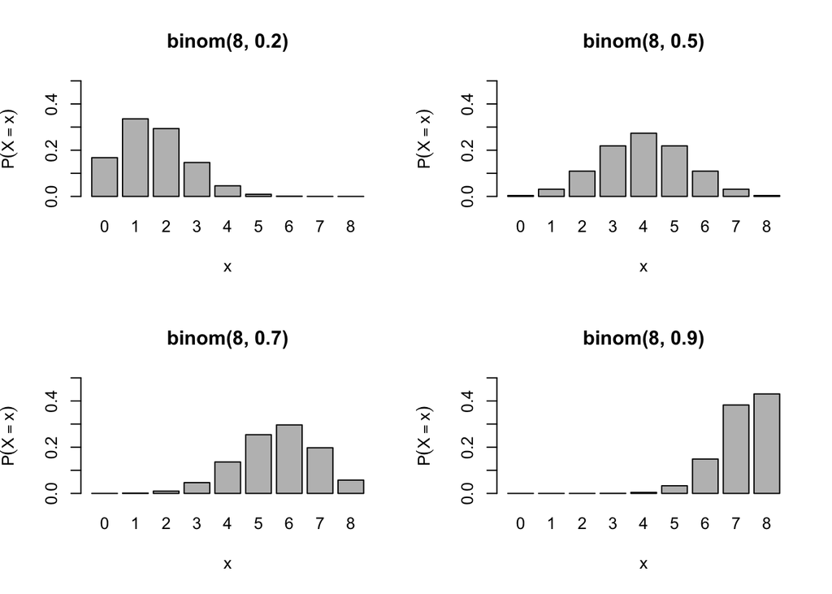

```r
n <- 8
x <- 0:n
myplot <- function(p) {
  barplot(dbinom(x,n,p),
          names.arg = x,
          ylim=c(0,.5),
          main=paste("binom(",n,", ",p,")", sep=""),
          xlab="x",
          ylab=expression(P(X==x)))
}
par(mfrow=c(2,2))
for (p in c(.2,.5,.7,.9)) {
  myplot(p)
}
```

## Poisson

Imagine doing many independent $\mathrm{Bernoulli}(p)$ trials, in each of which success is very rare. For example, the number of car accidents in Melbourne in a single day, where each of thousands of drivers has a very small chance of accident.

While we may use $\text{binom}(n,p)$ with large $n$ and small $p$, we could be in trouble because computers cannot handle extremely large or small values very well. An alternative modelling option is $\text{pois}(\lambda)$ with $\lambda\approx np$. Here is why.

Let $Y_n \sim \text{binom}(n,p)$ such that $p=\lambda/n$ for some $\lambda>0$. Then,

$$\begin{align}
P(Y_n=x) &= \binom{n}{x}p^x(1-p)^{n-x}\\
&= \frac{n\cdot(n-1)\dotsm(n-x+1)}{x!}\left(\frac{\lambda}{n}\right)^x\left(1-\frac{\lambda}{n}\right)^{n-x}\\
&= 1\cdot\frac{n-1}{n}\dotsm\frac{n-x+1}{n}\frac{\lambda^x}{x!}\left(1-\frac{\lambda}{n}\right)^{n}\left(1-\frac{\lambda}{n}\right)^{-x}\\
&\to 1\cdot 1\dotsm 1\frac{\lambda^x}{x!}e^{-\lambda}1 \text{ as } n\to\infty\\
&= \frac{e^{-\lambda}\lambda^x}{x!}
\end{align}$$

which is the PMF of $\mathrm{pois}(\lambda)$. The limit
$$\lim_{n\to\infty} P(Y_n=x) = \frac{e^{-\lambda}\lambda^x}{x!}$$
is called the *law of rare events*.

As indicated by $n\to\infty$, the support is $\mathbb{Z}_{\geq0}=\{0,1,\dots\}$.

Both mean and variance are equal to $\lambda$.

An important property of $\text{pois}(\lambda)$ is the following. Suppose $X_1,\dots,X_n$ are independent Poisson random variables with the corresponding parameters $\lambda_1,\dots\lambda_n$. Then,
$$X_1+\dots+X_n = \text{pois}(\lambda_1+\dots+\lambda_n) .$$
Here is a proof for $n=2$, which lets us generalise to $n>2$ by induction.

$$\begin{align}
P(X_1+X_2=n) &= \sum_{m=0}^n P(X_1=m)P(X_2=n-m)\\
&= \sum_{m=0}^n \frac{e^{-\lambda_1} \lambda_1^m}{m!}\cdot\frac{e^{-\lambda_2} \lambda_2^{n-m}}{(n-m)!}\\
&= \frac{e^{-(\lambda_1+\lambda_2)} (\lambda_1+\lambda_2)^n}{n!} \cdot \sum_{m=0}^n\binom{n}{m}\left(\frac{\lambda_1}{\lambda_1+\lambda_2}\right)^m\left(\frac{\lambda_2}{\lambda_1+\lambda_2}\right)^{n-m}\\
&= \frac{e^{-(\lambda_1+\lambda_2)} (\lambda_1+\lambda_2)^n}{n!}
\end{align}$$

because the summand is the PMF for $\text{binom}\left(n,\frac{\lambda_1}{\lambda_1+\lambda_2}\right)$.

Let’s compare $X\sim \text{pois}(\lambda)$ and $Y\sim \text{binom}(n,p)$ such that $\lambda = np$. Suppose $\lambda=1$ for simplicity and $n=10^4$.

```r
lambda <- 1
n <- 1e4
x <- c(0,2,5)
```

| $x$ | $P(X=x)$ | $P(Y=x)$ |
| --- | --- | --- |
| 0 | 0.3678794 | 0.367861 |
| 2 | 0.1839397 | 0.1839489 |
| 5 | 0.0030657 | 0.003064 |

Even with a moderate $n$, Poisson provides reasonable approximation of Binomial.

Here are some of PMF plots with varying $\lambda$.

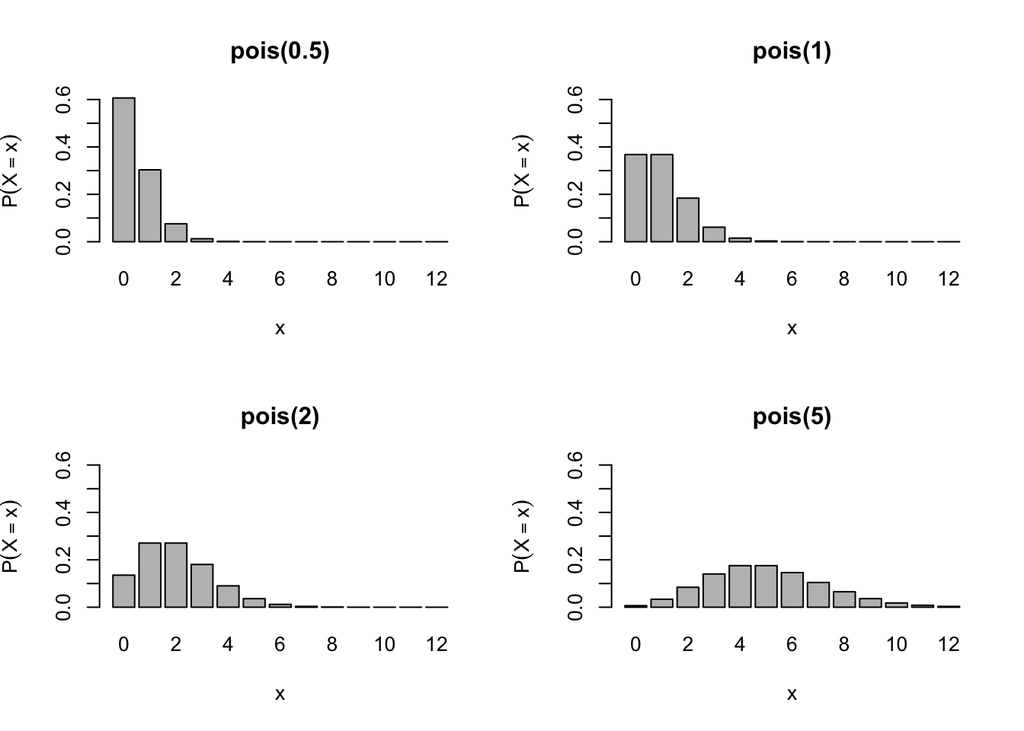

```r
n <- 12
x <- 0:n
myplot <- function(l) {
  barplot(dpois(x,l),
          names.arg = x,
          ylim=c(0,.6),
          main=paste("pois(",l,")", sep=""),
          xlab="x",
          ylab=expression(P(X==x)))
}
par(mfrow=c(2,2))
for (l in c(.5,1,2,5)) {
  myplot(l)
}
```

## Geometric

Imagine doing independent $\mathrm{Bernoulli}(p)$ trials **indefinitely** until we see the first success. Let $X$ denote the number of $0$ before getting the first $1$. Then, $X\sim \text{geom}(p)$.

> N.B. Some authors define $X$ to be the number of trials, and we also do so in Poisson process below.

Formally, let $B_1,B_2\dots \sim \text{Bernoulli}(p)$. Then,
$$X = \inf\{n\in\mathbb{Z}_{>0} : B_n=1\}-1 .$$

> We cannot really use $\min\{ \}$ because technically, albeit extremely unlikely, it may never happen.

Given the definition, the support is $\mathbb{Z}_{\geq0}=\{0,1,\dots\}$.

The derivation of PMF is easier than $\text{binom}(n,p)$, as it simply continues to multiply the failure probability $1-p$ until the last success probability $p$.

$$\begin{align}
P(X=x) &= P(B_1=0,B_2=0,\dots,B_x=0,B_{x+1}=1))\\
&= P(B_1=0) \dotsm P(B_x=0)P(B_{x+1}=1)\\
&= (1-p)^xp\\\\
\mathbb{E}X &= \sum_{x=0}^\infty xP(X=x)\\
&= \sum_{x=0}^\infty x(1-p)^xp\\
&= p(1-p)\sum_{x=0}^\infty x(1-p)^{x-1}\\
&= p(1-p)\left(-\sum_{x=0}^\infty \frac{d}{dp}(1-p)^{x}\right)\\
&= p(1-p)\frac{d}{dp}\left(-\sum_{x=0}^\infty (1-p)^{x}\right)\\
&= p(1-p)\frac{d}{dp}\left(-\frac{1}{p}\right)\\
&= \frac{1-p}{p}\\\\
\operatorname{Var} X &= \mathbb{E}(X^2) - (\mathbb{E}X)^2\\
&= \mathbb{E}(X(X-1))+\mathbb{E}X-(\mathbb{E}X)^2\\
&= \frac{1-p}{p^2}
\end{align}$$

> We may interchange the order of summation and differentiation in a geometric series.

Here are some of PMF plots with varying $p$.

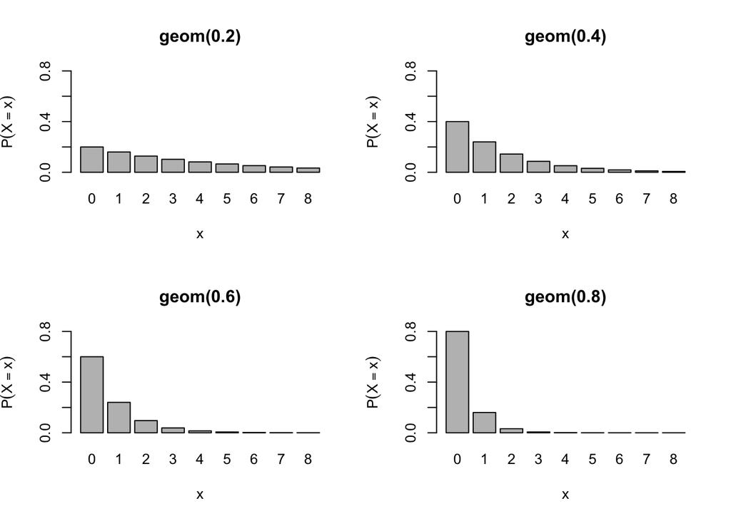

```r
n <- 8
x <- 0:n
myplot <- function(p) {
  barplot(dgeom(x,p),
          names.arg = x,
          ylim=c(0,.8),
          main=paste("geom(",p,")", sep=""),
          xlab="x",
          ylab=expression(P(X==x)))
}
par(mfrow=c(2,2))
for (p in c(.2,.4,.6,.8)) {
  myplot(p)
}
```

## Negative binomial

Despite the possibly confusing name, this is simply a generalised version of the geometric distribution: instead of the first success, we wait until $r$ successes.

Imagine doing independent $\mathrm{Bernoulli}(p)$ trials indefinitely until we see $r$ successes. Let $X$ denote the number of $0$ before getting $r$ number of $1$s. Then, $X\sim \text{nbinom}(r,p)$.

Conveniently, we may see $X\sim \text{nbinom}(r,p)$ as the sum of $r$ independent $\text{geom}(p)$ random variables. Thus, the mean and variance are particularly easy to compute:

$$\begin{align}
\mathbb{E}X &= r\frac{1-p}{p}\\
\operatorname{Var} X &= r\frac{1-p}{p^2}
\end{align}$$

To derive the PMF, notice first the following. If the $r$-th success is on trial $y$, then the previous $r-1$ successes can occur anywhere in the previous $y−1$ trials. Thus, there are $\binom{y-1}{r-1}$ ways we can get the $r$-th success on the $y$-th trial. Each of these ways has probability $(1-p)^{y-r}p^r$, so putting $x=y-r$, we get:
$$P(X=x) = \binom{r+x-1}{r-1}(1-p)^{x}p^r .$$

Here are some of PMF plots with varying $p$.

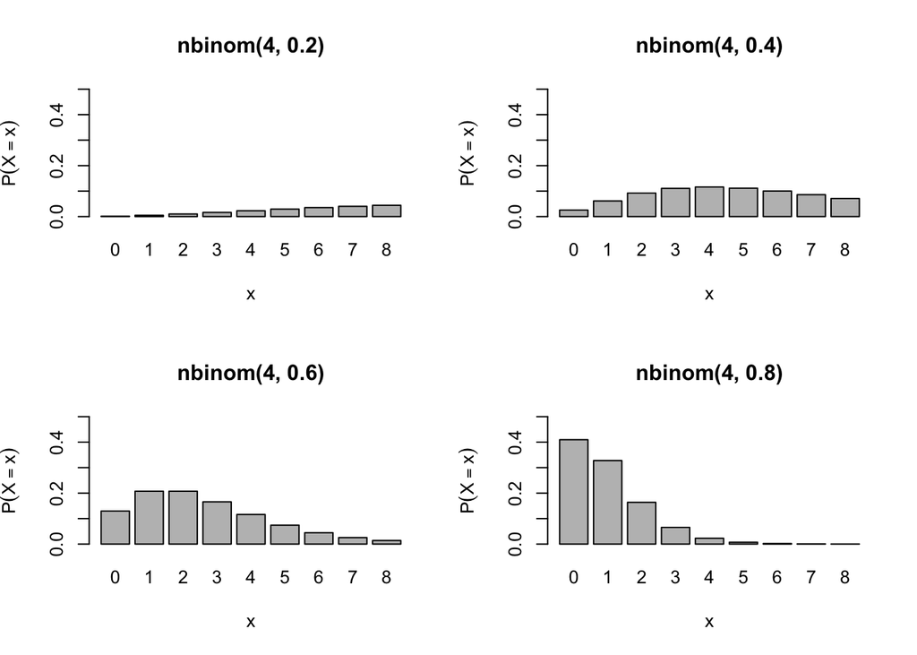

```r
n <- 8
x <- 0:n
myplot <- function(p) {
  barplot(dnbinom(x,4,p),
          names.arg = x,
          ylim=c(0,.5),
          main=paste("nbinom(",4,", ",p,")", sep=""),
          xlab="x",
          ylab=expression(P(X==x)))
}
par(mfrow=c(2,2))
for (p in c(.2,.4,.6,.8)) {
  myplot(p)
}
```